# Linear Regression In-Class Exercises — Revised Solutions

Maria Cuellar

2026-10-08

```r
library(tidyverse)
```

# Linear Regression: Riverton Crime

Use `riverton-crime.csv`. We will examine the relationship between number of prior arrests and time served.

```r
dat <- read_csv("/Users/mariacuellar/Github/crim_data_analysis/data/riverton-crime1.csv", show_col_types = FALSE)
```

## Question 1: Visual EDA

**Question.** Create a scatterplot with `num_prior_arrests` on the x-axis and `time_served_months` on the y-axis. Describe the direction, form, and strength of the relationship.

**Solution.**

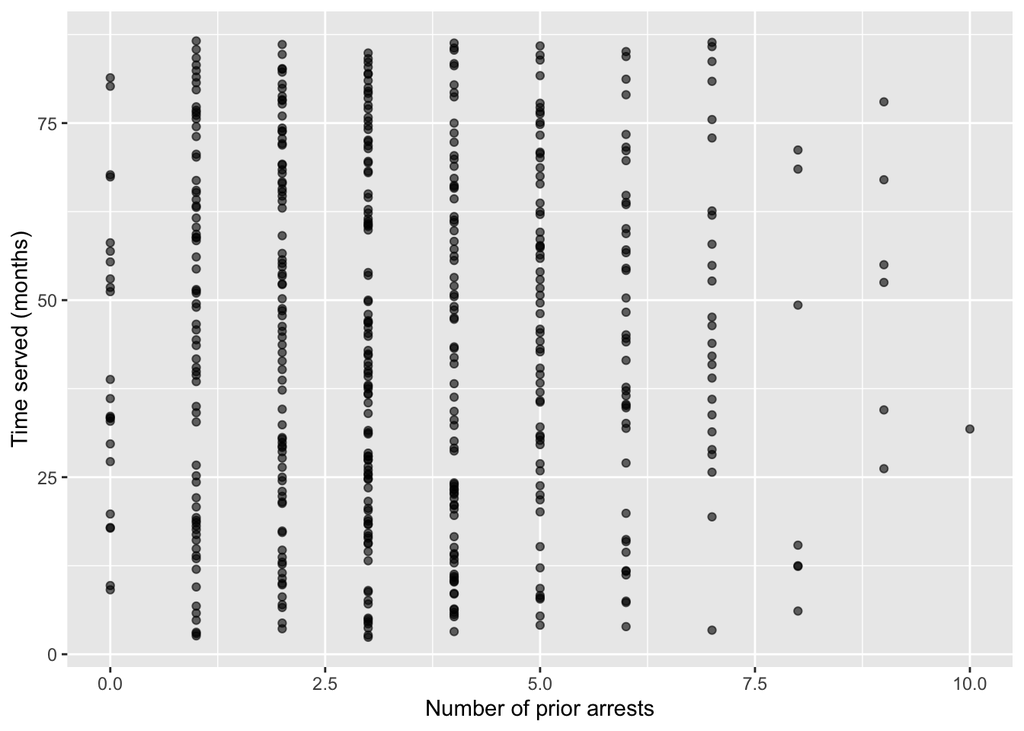

```r
ggplot(dat, aes(x = num_prior_arrests, y = time_served_months)) +
  geom_point(alpha = 0.6) +
  labs(x = "Number of prior arrests", y = "Time served (months)")
```

## Question 2: Fit the initial model

**Question.** Regress time served on number of prior arrests. Identify the outcome and explanatory variables.

**Solution.**

```r
model_riverton <- lm(time_served_months ~ num_prior_arrests, data = dat)
summary(model_riverton)
```

```
##
## Call:
## lm(formula = time_served_months ~ num_prior_arrests, data = dat)
##
## Residuals:
##     Min      1Q  Median      3Q     Max
## -42.067 -21.036  -0.005  21.205  42.288
##
## Coefficients:
##                   Estimate Std. Error t value Pr(>|t|)
## (Intercept)       44.23440    2.15625  20.514   <2e-16 ***
## num_prior_arrests  0.07739    0.54185   0.143    0.886
## ---
## Signif. codes:  0 '***' 0.001 '**' 0.01 '*' 0.05 '.' 0.1 ' ' 1
##
## Residual standard error: 24.41 on 498 degrees of freedom
## Multiple R-squared:  4.096e-05,  Adjusted R-squared:  -0.001967
## F-statistic: 0.0204 on 1 and 498 DF,  p-value: 0.8865
```

Outcome (Y): `time_served_months`. Explanatory variable (X): `num_prior_arrests`.

## Question 3: Equation and slope

**Question.** Write the fitted regression equation and interpret its slope.

## Question 4: Add a fitted line

**Question.** Add the regression line to your scatterplot. Is the line a reasonable summary?

**Solution.**

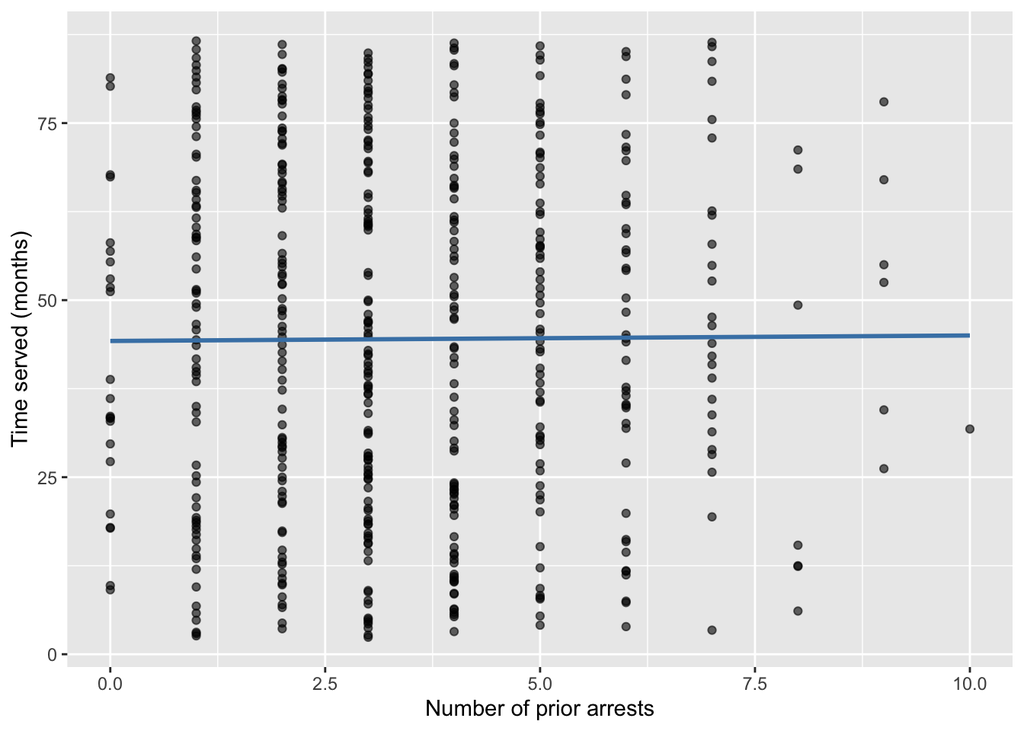

```r
ggplot(dat, aes(x = num_prior_arrests, y = time_served_months)) +
  geom_point(alpha = 0.6) +
  geom_smooth(method = "lm", se = FALSE, color = "steelblue") +
  labs(x = "Number of prior arrests", y = "Time served (months)")
```

The line summarizes the slight average positive trend, but individual points vary widely around it.

## Question 5: Prediction

**Question.** Predict time served for a person with five prior arrests.

**Solution.**

```r
predict(model_riverton, newdata = tibble(num_prior_arrests = 5))
```

```
##        1
## 44.62135
```

## Question 6: R-squared and causation

# Question 7 (20 points): Income and Happiness

Use `income_2.csv` to study the association between **income** (X) and **happiness** (Y). Follow the full regression workflow, retaining both the original analysis and a sensitivity analysis excluding influential observations.

## 7(a) Load and explore (4 points)

**Question.** Load the dataset. Create a scatterplot without a fitted line, describe the direction/form/strength, and calculate Pearson’s correlation if appropriate.

**Solution.**

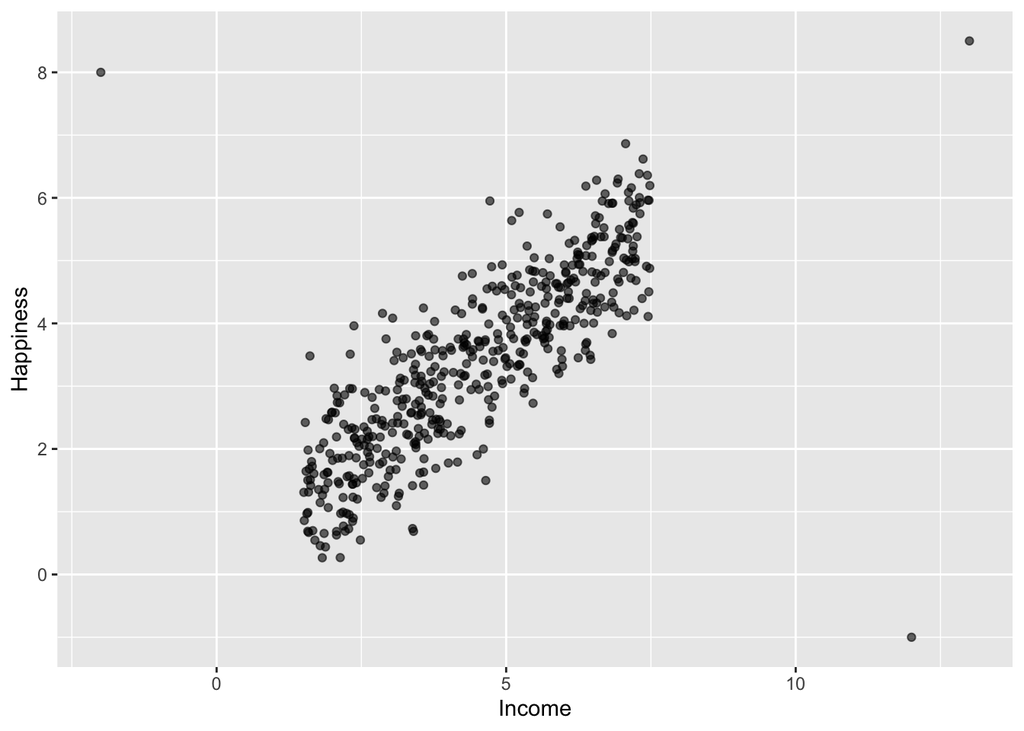

```r
income_dat <- read_csv("/Users/mariacuellar/Github/crim_data_analysis/data/income_2.csv", show_col_types = FALSE)

# Limit to complete cases for the two analysis variables so that
# Cook's distances and dataset rows remain aligned.
income_complete <- income_dat %>%
  filter(!is.na(income), !is.na(happiness)) %>%
  mutate(obs_id = row_number())

ggplot(income_complete, aes(x = income, y = happiness)) +
  geom_point(alpha = 0.6) +
  labs(x = "Income", y = "Happiness")
```

```r
cor(income_complete$income, income_complete$happiness)
```

```
## [1] 0.7802075
```

In the original supplied solution, Pearson’s correlation was **0.780**, suggesting a **strong positive linear association overall**. The scatterplot should also be checked for unusual observations that may affect this summary; correlation can be sensitive to them. Do not interpret this association causally.

## 7(b) Fit the original regression model (4 points)

**Question.** Fit the linear model predicting happiness from income. Report the intercept, slope, and p-value for the slope.

**Solution.**

```r
model_full <- lm(happiness ~ income, data = income_complete)
summary(model_full)
```

```
##
## Call:
## lm(formula = happiness ~ income, data = income_complete)
##
## Residuals:
##     Min      1Q  Median      3Q     Max
## -9.1306 -0.4921 -0.0224  0.4988  8.6770
##
## Coefficients:
##             Estimate Std. Error t value Pr(>|t|)
## (Intercept)  0.58125    0.10937   5.315 1.61e-07 ***
## income       0.62911    0.02258  27.862  < 2e-16 ***
## ---
## Signif. codes:  0 '***' 0.001 '**' 0.01 '*' 0.05 '.' 0.1 ' ' 1
##
## Residual standard error: 0.9232 on 499 degrees of freedom
## Multiple R-squared:  0.6087, Adjusted R-squared:  0.6079
## F-statistic: 776.3 on 1 and 499 DF,  p-value: < 2.2e-16
```

In the original supplied solution, the estimated intercept was **0.5813**, the slope was **0.6291**, and the slope p-value was **p < 2 × 10^-16** (report simply as **p < 0.001**). The estimated equation was

$$\widehat{\mathrm{happiness}}=0.5813+0.6291\times
\mathrm{income}.$$

The original R-squared was **0.6087**. These numerical results refer to the **full sample**.

## 7(c) Investigate influential observations (4 points)

**Question.** Plot Cook’s distance for the first model. Use **Cook’s distance > 0.05** as a *screening rule* to flag potentially influential observations. How many are flagged? Create a new dataset excluding them, then fit a second model. Do not overwrite the original model.

**Solution.**

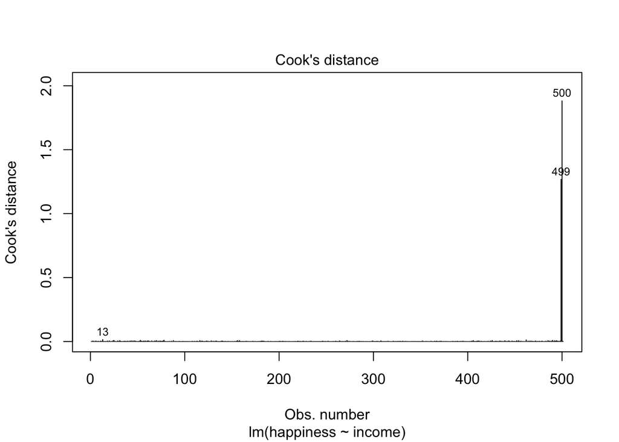

```r
plot(model_full, which = 4)  # Cook's distance; R labels up to 3 points
```

```r
# Calculate Cook's distance for EVERY observation used by the model.
income_with_cooks <- income_complete %>%
  mutate(cooks_d = cooks.distance(model_full))

# Flag however many exceed the chosen cutoff (possibly 0, 1, 3, ...).
flagged <- income_with_cooks %>%
  filter(cooks_d > 0.05)

flagged %>% select(obs_id, income, happiness, cooks_d)
```

```
## # A tibble: 2 × 4
##   obs_id income happiness cooks_d
##    <int>  <dbl>     <dbl>   <dbl>
## 1    499     -2         8    1.27
## 2    500     12        -1    1.88
```

```r
nrow(flagged)
```

```
## [1] 2
```

```r
# Make the sensitivity-analysis dataset.
income_no_influential <- income_with_cooks %>%
  filter(cooks_d <= 0.05)

# Fit a separate model; retain model_full.
model_reduced <- lm(happiness ~ income, data = income_no_influential)
summary(model_reduced)
```

```
##
## Call:
## lm(formula = happiness ~ income, data = income_no_influential)
##
## Residuals:
##      Min       1Q   Median       3Q      Max
## -2.02195 -0.48540  0.03816  0.45760  2.38128
##
## Coefficients:
##             Estimate Std. Error t value Pr(>|t|)
## (Intercept)  0.22618    0.08739   2.588  0.00993 **
## income       0.70850    0.01812  39.101  < 2e-16 ***
## ---
## Signif. codes:  0 '***' 0.001 '**' 0.01 '*' 0.05 '.' 0.1 ' ' 1
##
## Residual standard error: 0.7187 on 497 degrees of freedom
## Multiple R-squared:  0.7547, Adjusted R-squared:  0.7542
## F-statistic:  1529 on 1 and 497 DF,  p-value: < 2.2e-16
```

**Interpretation.** Observations with Cook’s distance over 0.05 warrant investigation because they can affect the fitted regression coefficients. **They are not automatically errors and should not simply be discarded from the main analysis.** We fit a second model without them to find out whether the conclusions are sensitive to those observations. The cutoff 0.05 is a teaching convention for this exercise, *not* the default threshold represented by the reference lines on all R diagnostic plots. R typically labels at most three points in `plot(model_full, which = 4)`, but the number above a specified cutoff can be different.

**Important:** This code deliberately constructs `income_complete` first, so Cook’s distances correspond to the exact rows in `income_with_cooks`. This avoids row-alignment errors if the original CSV has missing data.

## 7(d) Compare diagnostics and model fit (5 points)

**Question.** Examine the diagnostic plots for **both** models. Discuss linearity, approximately constant error variance, and approximate normality of the residuals. Assess independence from the study design. Compare R-squared and the estimated slopes across models.

**Solution.**

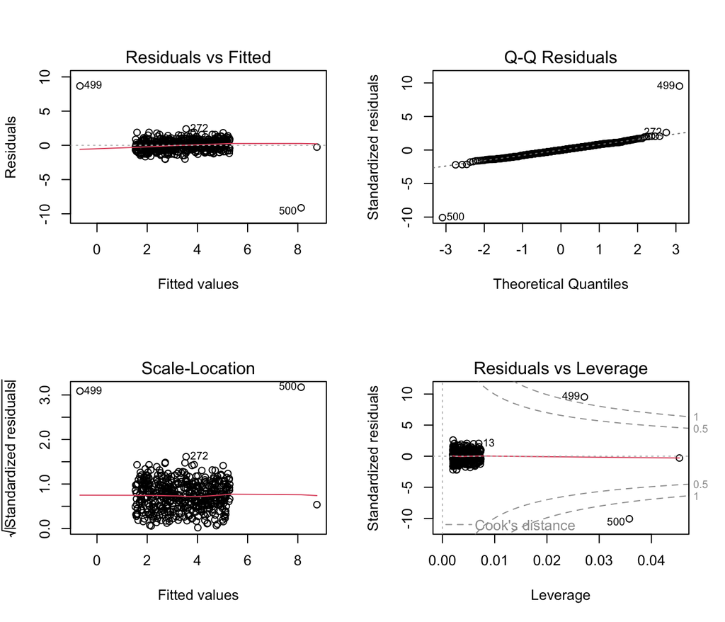

```r
par(mfrow = c(2, 2))
plot(model_full)       # All four standard plots
```

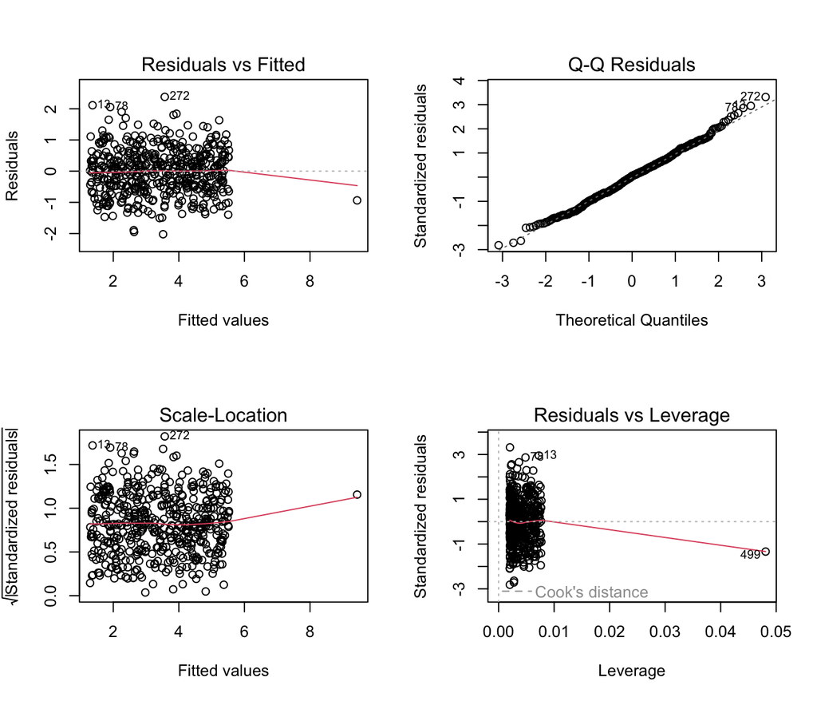

```r
par(mfrow = c(2, 2))
plot(model_reduced)    # Four plots for reduced sample
```

```r
par(mfrow = c(1, 1))
```

How to interpret the plots:

- **Residuals vs Fitted:** Look for no systematic curved pattern (linearity) and roughly similar vertical spread across the fitted values (constant variance).
- **Normal Q-Q:** Points approximately following the reference line suggest errors are reasonably compatible with normality; strong tail departures indicate possible violations.
- **Scale-Location:** A roughly horizontal pattern with no increasing/decreasing spread is consistent with constant variance.
- **Residuals vs Leverage:** Helps identify high-leverage and influential observations. Re-check for influential observations after fitting the reduced model.
- **Independence:** Cannot be verified by these four plots alone; consider whether observations were sampled independently or whether there are clusters/repeated measurements.

R-squared describes **goodness of fit**, not whether the model assumptions are met. The original R-squared of 0.6087 does not by itself validate the regression model.

```r
model_comparison <- tibble(
  model = c("All observations", "Without flagged observations"),
  n = c(nobs(model_full), nobs(model_reduced)),
  intercept = c(coef(model_full)[1], coef(model_reduced)[1]),
  slope = c(coef(model_full)[2], coef(model_reduced)[2]),
  p_value_slope = c(coef(summary(model_full))[2, 4],
                    coef(summary(model_reduced))[2, 4]),
  r_squared = c(summary(model_full)$r.squared,
                summary(model_reduced)$r.squared)
)
model_comparison
```

```
## # A tibble: 2 × 6
##   model                            n intercept slope p_value_slope r_squared
##   <chr>                        <int>     <dbl> <dbl>         <dbl>     <dbl>
## 1 All observations               501     0.581 0.629     9.65e-104     0.609
## 2 Without flagged observations   499     0.226 0.708     9.21e-154     0.755
```

**Expected discussion:** State whether removing flagged points noticeably changes the slope, statistical significance, R-squared, or residual diagnostics. Whether the reduced model is preferable cannot be decided solely because its R-squared is higher. The answer should be based on the actual rendered results; numerical coefficients for the **reduced model** are intentionally calculated by the code rather than invented here.

## 7(e) Interpret the slopes and conclusions (3 points)

**Question.** Interpret the slopes from both models in context. For each slope, report whether the association is statistically significant at the 0.05 level and give the p-value. Did removing influential observations change the substantive conclusion?

**Solution.**

For the original model: **For each one-unit increase in income, predicted happiness increases by about 0.629 units on average. The association is statistically significant (p < 0.001).** The units of `income` and `happiness` should be taken from the dataset codebook; do not assume income is in dollars or happiness is a standard 1–10 scale without verification.

For the reduced model, use the second row of `model_comparison` and write: **For each one-unit increase in income, predicted happiness [increases/decreases] by [estimated slope] units on average; [statistically significant/not statistically significant] (p = [p-value]).** Then compare the two models, explaining whether the result is sensitive to the flagged observations.

**Teaching note:** Normality matters mainly for exact small-sample t-tests/confidence intervals, not for computing the least-squares line. Never remove observations *solely* to get a significant p-value or prettier diagnostics.

**Grading suggestion for Question 7:** (a) EDA 4; (b) original fit 4; (c) Cook’s distance + sensitivity fit 4; (d) diagnostics + comparison 5; (e) interpretation/inference 3. **Total: 20 points.**